# A/B testing, Bayes style

## But why?

So that you understand your test results correctly, including the uncertainty in them, without the p-value hassle.

### Also:

Gentle introduction to Bayesian methods.

### After this

You understand the results of Bayesin analysis, and are familiar with terms such as *posterior*, *prior*, and *statistical model*.

## Our case

Reaktor website has a one-click purchase of a fixed-price-scope schedule-team agile software project, or whatever. More to the point, there are *two variants of the button*. Which is better? How much?

**What do we measure**?

Visits on the page and button clicks.

Below are some simulated data, with pre-set click rates. Those are the underlying rates that we do not know in the measurement situation, and which we are after. Per day, we have on average 1500 visits on the page, of which 20% see the option **B**, for a total of six days.

Note that if you re-knit this document from the R Markdown file, data is re-generated and the results will change. How clear the difference between **A** and **B** looks like, from the raw click rates, *varies by run*. *That’s also how it is in real life!* Our goal is to get beyond that variation to get an idea of how things are in reality.

Reality here refers to the pre-set click rates. In practice we also have pre-set click rates, but they are set by nature. We do not observe them directly. We observe only data.

```r
rate.A <- 0.052
rate.B <- 0.068

example <- click.data(rate.A, rate.B, mean.visits=1500, test.group=0.2, days=6)

print(example)
```

```
##    day variant visits clicks click.rate
## 1    1       A   1450     62 0.04275862
## 2    1       B    327     17 0.05198777
## 3    2       A   1334     71 0.05322339
## 4    2       B    213     16 0.07511737
## 5    3       A   1284     64 0.04984424
## 6    3       B    265     23 0.08679245
## 7    4       A   1342     79 0.05886736
## 8    4       B    245      8 0.03265306
## 9    5       A   1107     59 0.05329720
## 10   5       B    320     23 0.07187500
## 11   6       A    885     52 0.05875706
## 12   6       B    316     20 0.06329114
```

So this is the (simulated) setup, and the data above is all we know from measurements.

That’s how the data looks like as plots:

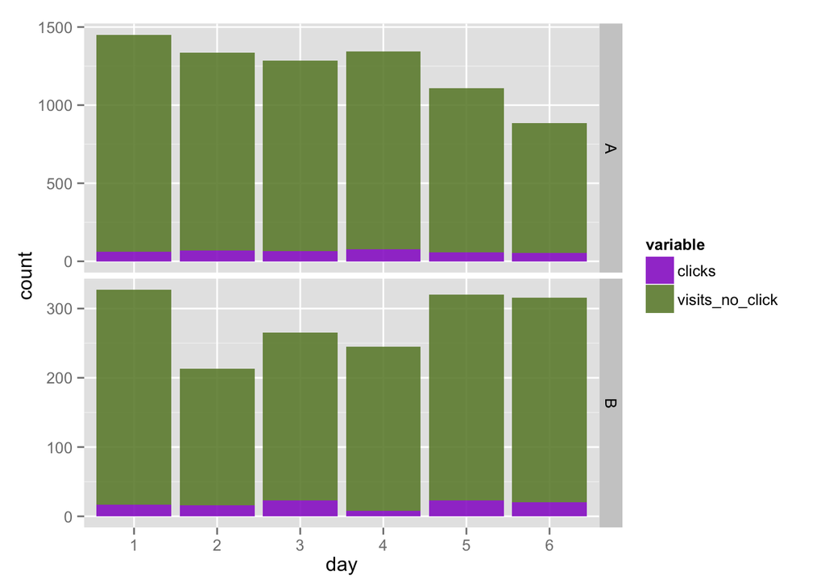

```r
example.plots <- click.plots(example)
print(example.plots$histograms)
```

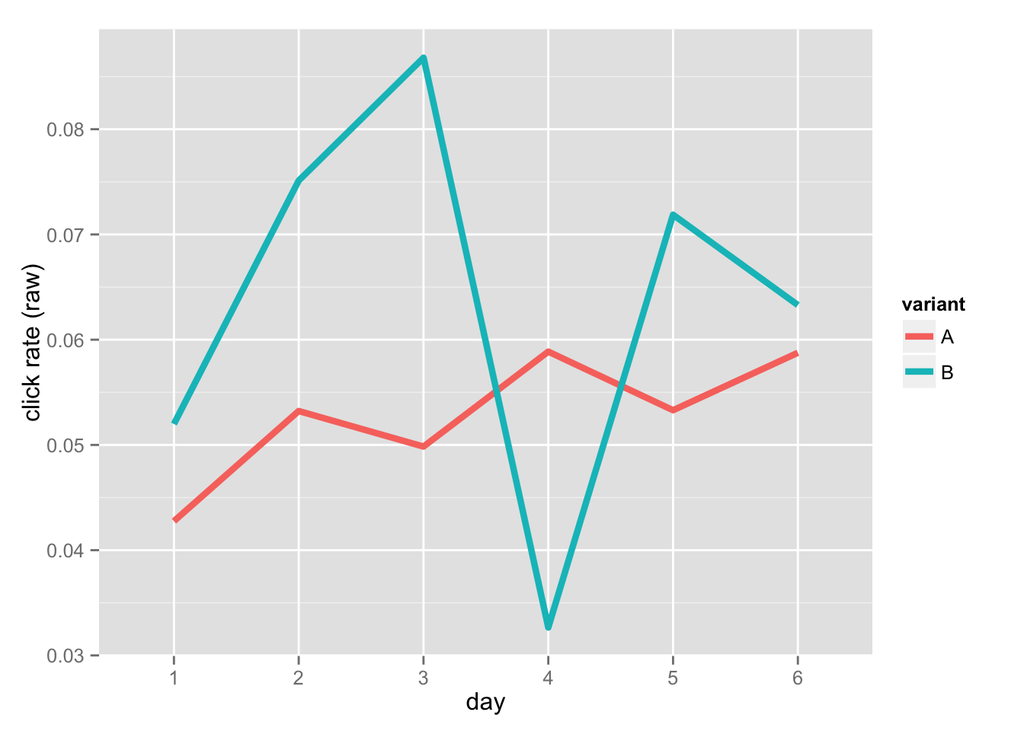

```r
print(example.plots$rates)
```

## Let’s mathematics

(If you want results without too much understanding, skip to the practical section below.)

*What do we want to know?* The pre-defined click rates, set by nature, $\theta_A$ and $\theta_B$ that the visitor buys a project when shown either button **A** or **B**. In our example where we played nature and generated the data, the rates were **rate.A** and **rate.B**.

*What do we have?* Click and visit counts, $k$ and $N$.

### A statistical model

Think how the data is generated.

If the click rate or the change to click is $\theta$ per visit, the probability to get a click/no-click sequence 00101 is

$(1-\theta)\,(1-\theta)\,\theta\,(1-\theta)\,\theta\;.$

For a *single* sequence of $k$ clicks and $N-k$ non-clicks, the probability is

$\theta^k\, (1-\theta)^{N-k}\;.$

The probability to get *any* sequence with $k$ clicks and $N-k$ non-cliks is

$\text{(Number of sequences with $k$ clicks and $N-k$ non-clicks)} \times \theta^k\, (1-\theta)^{N-k}\;.$

That number of sequences does not depend on click rate, so we don’t need to care about it really. But for completeness, it is $N!/(k!(N-k)!)$. So the probability to get a data, or in other words any sequence, with $k$ clicks is

$p(k, N|\theta) = \frac{N!}{k!(N-k)!} \theta^k\, (1-\theta)^{N-k}\, \propto\, \theta^k\, (1-\theta)^{N-k}\;.$

That “$\propto$” is “proportional to”, and just means that we eventually can skip the constant (as we will see). (Also note that the probability is in no way absolute, the same in all settings, but conditional on the click rate $\theta$.)

Okey, so we know the probability of data of length $N$ with $k$ clicks, given click rate $\theta$. Sadly, this is the wrong way, as it always tends to be statistics.

Now we have the probability of data we have seen, given reality. But that reality is unknown! What we want is the probability of reality given the data se have.

### Enter Bayes

Think about the conditional probability for a while. What is the probability to see a full moon tonight? It is, to a first approximation, the probability that it is full-moon time in general, times the probability that you see the moon, if it is there:

$p(\text{full moon & seen}) = p(\text{seen}\, |\, \text{full moon}) \times p(\text{full moon})$.

You can invent better examples, but the general idea is that for two events $X$ and $Y$, the probability of both occurring is the probability that the first ($X$) occurs, times the probability that $Y$ occurs given $X$, or vice versa.

$p(X, Y) = p(X | Y)\, p(Y) = p(Y | X)\, p(X)\;.$

This is quite self-evident, but powerful when applied in a more abstract context. What is the probability of seeing data $D$ and being in world $W$?

$p(D, W) = p(D | W)\, p(W) = p(W | D)\, p(D)\;.$

In other words,

$p(W | D) = \frac{p(D | W)\, p(W)}{p(D)}\;.$

This is quite remarkable, called *the Bayes rule*. It says that if you have *a model* that gives the probability of data $D$, given a state of the world $W$, you can get the probability of *world itself, given data*, by simple multiplication (or so it seems).

How does this apply to our click rates? Our data $D$ are the observed $k, N$, and our world is described by one simple probability, the click rate $\theta$. Applying Bayes rule, we have $p(\theta | k, N) = \frac{p(k, N\, | \, \theta)\, p(\theta)}{p(k, N)} = \frac{N!}{k!(N-k)!} \theta^k\, (1-\theta)^{N-k}\; \frac{p(\theta)}{p(k, N)}\;.$

At this point it helps a lot to note that in a practical setting the data $N$ and $k$ are what they are, they do not change. If we are after $p(\theta\,|\,N, k)$, and especially willing to mainly know how likely different click rates $\theta$ are *compared to each other*, we can drop all constant multiplies. That is, we can drop all multipliers where $\theta$ does not appear. This includes the weird “probability of data” $p(k, N)$ which is constant anyway, as well as the binomial coefficients $N!/(k!(N-k)!)$ originally arising from the number of possible click sequences. We are then left with just

$p(\theta\, |\, k, N) \propto \theta^k\, (1-\theta)^{N-k}\;p(\theta)\;.$ The constant left out form our “propto” or " $\propto$ can be later determined, if needed, from the fact that the sum or integral of the probabilities need to be one: $\int p(\theta\,|\,k, N)\;d\theta$ = 1. (If you google for “beta distribution”, you’ll find the constant.)

The probability distribution $p(\theta\, |\, k, N)$ is called *the posterior*, because it carries our information of the world *after* the data.

There is one more thing: $p(\theta)$, or the probability of various click rates before any data. WTF is that? It is my prejudice or domain knowledge about how the click rates in general are, prior to seeing data. If I have no idea, a decent alternative is to set $p(\theta)=\text{const.}$, or that all click rates are equally good guesses. ($p(\theta)$ is called *prior*, and we’ll come back to it later.)

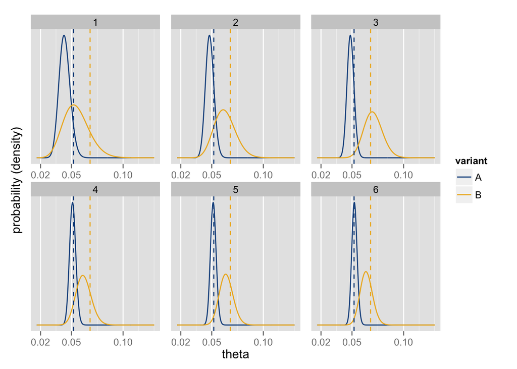

```r
example.posterior <- abtest.posteriorplot(example)
# quartz(width=14, height=6)
print(example.posterior$plot
      + geom_vline(xintercept=rate.A, linetype='dashed', colour="dodgerblue4")
      + geom_vline(xintercept=rate.B, linetype='dashed', colour="goldenrod2")
      + scale_color_manual(values=c("dodgerblue4", "goldenrod2"))
      + scale_y_continuous(breaks=NULL)
      + scale_x_continuous(breaks=c(.02, .05, .1))
      + xlab("theta") + ylab("probability (density)"))
```

## Getting practical

Happened so far: Given number of clicks $k$, and the total number of visits, $N$, we were able to compute the *probability distribution* of the underlying true click rate: $p(\theta\, |\, k, N) \propto \theta^k\, (1-\theta)^{N-k}\;.$

The underlying true click rate $\theta$ is called a *parameter* of our model. (We have only one parameter, in general there can be many, even thousands or millions.) Probability distributions parameters conditioned no data are called *posteriors*.

This particular posterior is of the mathematical form called *Beta distribution*. Not all posteriors are Beta distributed. Here the Beta arises because our model happens to be Binomial, and the prior is flat.

### Simulating from a posterior

In practice it is often easiest to describe posteriors by drawing random samples from them, instead of trying to manage the analytical form.

In R, for Beta distribution the relevant function is **rbeta()**.

Assume there is 212 visits in total, of which 13 lead to a positive response. We generate samples from the associated posterior $p(\theta)$, the true click rate:

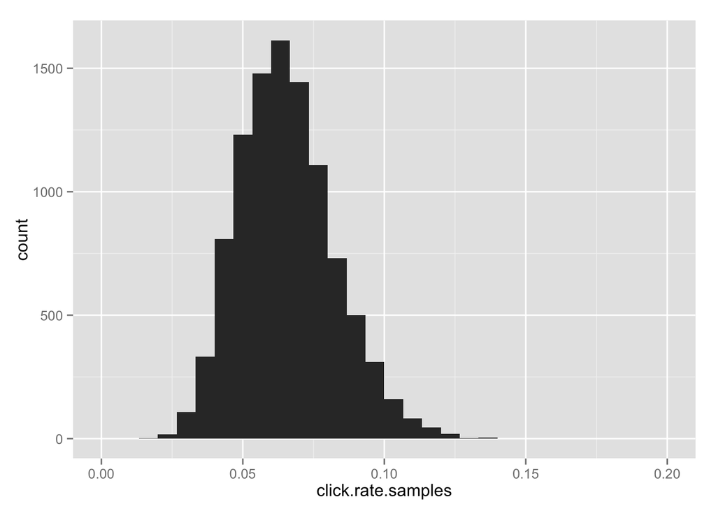

```r
click.rate.samples <- rbeta(10000, 13+1, 212-13+1)
qplot(click.rate.samples) + geom_histogram() + xlim(0, .2)
```

Those $+1$’s correspond to a flat prior $p(\theta)$. They basically say “Prior to data, I have no idea what the click rate is, or even if I have, I don’t want to tell.”.

The histogram of random draws approximates the analytical posterior:

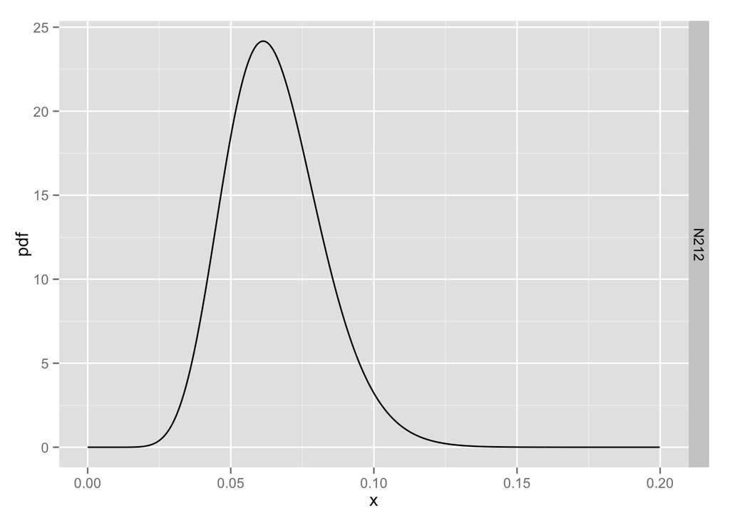

```r
betaplots(mean=13/212, sample.size=212) + xlim(0, .2)
```

Analytical posteriors, in terms of formulas or standard distributions like Beta are available only for simple models. If there are a lot of data, the posterior can often be approximated by the normal distribution, even if the model is not simple. Then there are models for which we cannot have a analytic posterior and not even a good approximation. But maybe surprisingly, we can often still get samples from the posterior. This may require heavy computation.

Here we stick with our particular simple model, and **rbeta()** is sufficient.

### How about the comparison of A and B?

Samples of click rate $\theta$ are possible states of the world, in terms of the underlying click rate. We can pair those up for treatments A and B to see how the difference is in possible worlds, given the data.

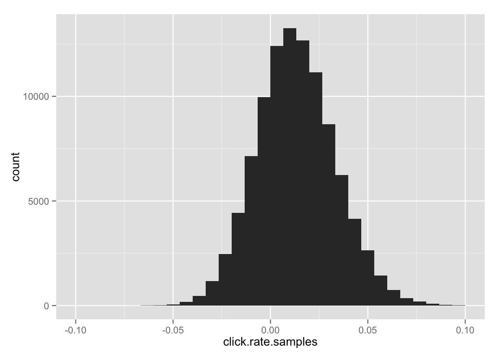

```r
click.rate.samples <- rbeta(100000, 13 +1, 212-13 +1) - rbeta(100000, 20 +1, 400-20 +1)
qplot(click.rate.samples) + geom_histogram() + xlim(-.10, .10)
```

What is the probability for the $(212, 13)$ case to have a larger click rate?

```r
sum(click.rate.samples>0)/length(click.rate.samples) # Or simply mean(...)
```

```
## [1] 0.74082
```

So click rate looks like larger in the first case, but we are far from sure.

Let’s look our example data again. We assume the click rate is same for each day, sum the data over days, and see how the posterior of the click rate looks like.

```r
example
```

```
##    day variant visits clicks click.rate
## 1    1       A   1450     62 0.04275862
## 2    1       B    327     17 0.05198777
## 3    2       A   1334     71 0.05322339
## 4    2       B    213     16 0.07511737
## 5    3       A   1284     64 0.04984424
## 6    3       B    265     23 0.08679245
## 7    4       A   1342     79 0.05886736
## 8    4       B    245      8 0.03265306
## 9    5       A   1107     59 0.05329720
## 10   5       B    320     23 0.07187500
## 11   6       A    885     52 0.05875706
## 12   6       B    316     20 0.06329114
```

```r
visits.a <- sum(example[example$variant=="A", "visits"])
visits.b <- sum(example[example$variant=="B", "visits"])
clicks.a <- sum(example[example$variant=="A", "clicks"])
clicks.b <- sum(example[example$variant=="B", "clicks"])

c(visits.a, visits.b, clicks.a, clicks.b)
```

```
## [1] 7402 1686  387  107
```

```r
rate.a <- rbeta(100000, 1 + clicks.a, 1 + visits.a - clicks.a)
rate.b <- rbeta(100000, 1 + clicks.b, 1 + visits.b - clicks.b)

c(mean(rate.a), mean(rate.b), mean(rate.a - rate.b))
```

```
## [1]  0.05240569  0.06397867 -0.01157299
```

```r
mean(rate.a > rate.b) # Probability of rate.a being larger
```

```
## [1] 0.03306
```

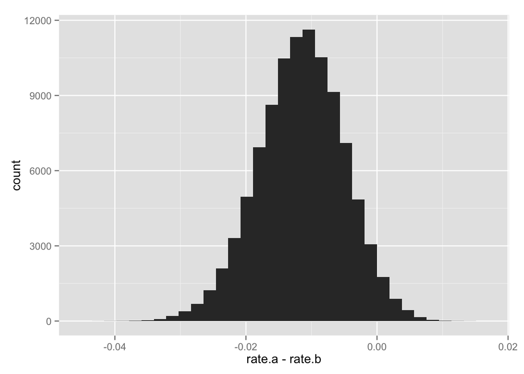

```r
qplot(rate.a-rate.b) + geom_histogram()
```

```r
quantile(rate.a-rate.b, c(.05/2, .5, 1-.05/2)) # Median and 95% confidence intervals
```

```
##          2.5%           50%         97.5%
## -0.0247370188 -0.0114127910  0.0007423867
```

### “I have no prior idea of the click rate” … what if you have?

Recall the general form of the posterior: $p(\theta\, |\, k, N) \propto \theta^k\, (1-\theta)^{N-k}\;p(\theta)\;.$ Prior knowledge about the click rate $\theta$ is encoded to the prior, $p(\theta)$. An informative $p(\theta)$ is not constant. A constant prior is convenient, for it leads the posterior to be the Beta distiribution, for which we have tools in many languages.

But there is a trick available for certain kinds of non-constant priors. If the prior is of the form $p(\theta) = \theta^{\alpha}\, (1-\theta)^{\beta}\;,$ then the posterior becomes $p(\theta\, |\, k, N) \propto \theta^{k+\alpha}\, (1-\theta)^{N-k+\beta}\;.$ So this is still a Beta distribution, just with different parameters.

Note the prior is *also* a Beta distribution! You can choose $\alpha$ and $\beta$ by plotting the prior with different values, and see which fits with our preconceptions. The prior below is with sampling:

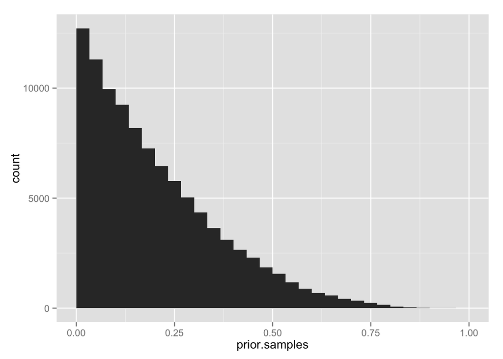

```r
prior.samples <- rbeta(100000, 1, 4)
qplot(prior.samples) + geom_histogram() + xlim(0, 1)
```

Another way to choose the prior is the note that $\alpha$ and $\beta$ are in the formula like virtual clicks and visits with no clicks, and $\alpha/(\alpha+\beta)$ is a virtual click rate. So you can guess a “prior click rate” $\alpha/(\alpha+\beta)$ and think about how much evidence you think you have, in terms of the number of virtual visits $\alpha + \beta$. How many clicks are needed to cancel your preconceptions? Again, it helps to plot the distributions. Below an analytic prior (no sampling), by misusing our posterior plotting function:

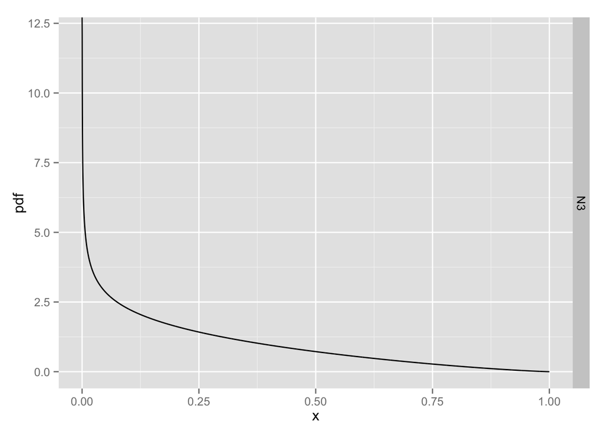

```r
betaplots(mean=.25, sample.size=3, prior=c(0, 0))
```

In general, a prior that melts into the “likelihood” part of the model is called *conjugate*. Non-conjugate priors can be used, but computations is more difficult.

Note that in objective settings, if you want to convince others, your prior must be somehow generally acceptable. Especially if you compare groups A and B, you should not have a different prior for different groups, at least not without a very strong reason.

### What happens to the posterior when data increases?

It gets narrower, and starts to resemble the gaussian (normal) distribution. The influence of prior vanishes, even if you had a strongly informative prior.

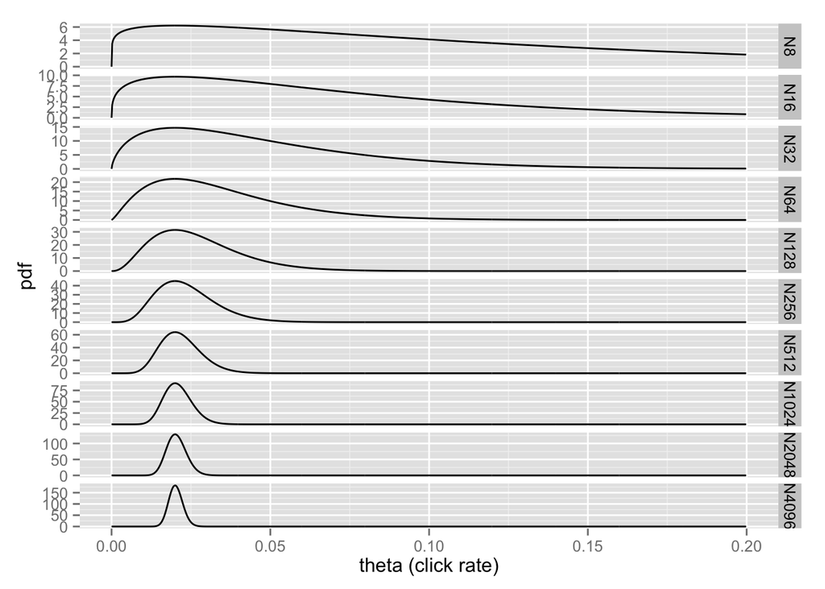

```r
betaplots(mean=0.02) + xlim(0, .2) + xlab("theta (click rate)")
```

### What is the classic A/B testing in this context? How about p-values?

Frequentist, classic significance test for the click rates assumes gaussian posteriors, and ignores the prior. The shape of the gaussian approximation can be quite easily computed from data. The problem then turns to comparing two normal distributions, and the concept of z-score appears.

Frequentist p-values are probabilities to get the difference in click rates you observed in data, or larger, if there is no real difference. Our probabilities for a difference of the click rates to be larger or smaller than zero are identical to frequentist p-values if (1) you have a lot of data; (2) click rate is not too small; (3) the frequentist p-value is “one-sided”, not “two-sided”; (4) prior is non-informative.

But even when the number is the same, the interpretation is different.

### Extensions to classic A/B testing

Multiple treatments, not just A and B.

Using covariates: the viewers have one or more known properties, and you want to see how they affect the click rate, or difference of click rates between groups.

Analyse temporal effects

Hierarchy for groups: A1, A2, A3, A4, B1, B2, B3, B4. You may find differences between A and B even if subgroup differences are not significant.

Cross designs: Alternate two or more variables simultaneously.

Continuous treatments: Instead of discrete groups, have a thing that varies continuously, such as a button size or color.

Incremental (sequential) experiments: get results when you have enough data, but don’t compromise the results by “waiting for significance”.

Automatic optimization: the system experiments all the time, and directs resources where posterior uncertainty is large and utilities are high.

### What you need to remember

Prior are your preconceptions.

Posterior is what is known after data.

Statistical model tells how we see the world in our experiment.

**rbeta()** or an equivalent. Samples are possible states of the world.

### Even more important things

We assume **unbiased sampling** from a population, and independent clicks.

Treatment effects vary by time, and results of a quick A/B test may be misleading.